# Identifying the enhancer gene pairs

Jenny Jakobsson

11/19/2020

# Combining the scores to predict enhancer gene pairs

The last step of the analysis now needs to be done. We want to combine our predicted enhancers with the differential expressed genes.

## Load the required files

We load the ATAC-seq, ChIP-seq for CBP and H3K27ac and PRO-seq(per CBP peak) data. The also rename the columns to distinguish them. We then also load the external data, in Situ and enhancer data. This data is used to find true enhancers in our data.

```r
# Load the ATAC seq loading scores
ATACseq.data = read.table(
  file = paste(params$workingDir, params$ATACseq.data, sep = ""),
  quote = "",
  sep = "\t",
  header = TRUE,
  stringsAsFactors = F
)
# Rename the columns
ATACseqInfo = ATACseq.data %>% dplyr::rename(
  "ATAC_Gd7" = Gd7,
  "ATAC_Toll10b" = Toll10b,
  "ATAC_Toll9" = Toll9,
  "ATAC_Time" = Time,
  "ATAC_Start" = Start,
  "ATAC_End" = End ,
  "ATAC_factor" = factor,
  "ATAC_direction" = direction,
)
```

```r
#Load the ChIPseq data for CBP
CBPInfo =  read.table(
  file = paste(params$workingDir, params$ChIPseqDir, params$CBP.data, sep = ""),
  quote = "",
  sep = "\t",
  header = TRUE,
  stringsAsFactors = F
)
# Rename the columns
CBPInfo = CBPInfo %>%
  dplyr::select(geneID, Gd7, Toll10b, Toll9) %>%
  dplyr::rename("CBP_Gd7" = Gd7,
                "CBP_Toll10b" = Toll10b,
                "CBP_Toll9" = Toll9)

# Load the ChIPseq data for H3K27ac
K27acInfo =  read.table(
  file = paste(params$workingDir, params$ChIPseqDir, params$K27ac.data, sep = "/"),
  quote = "",
  sep = "\t",
  header = TRUE,
  stringsAsFactors = F
)
# Rename the columns
K27acInfo = K27acInfo %>% dplyr::rename(
  "K27ac_geneID" = geneID,
  "K27ac_Start" = Start,
  "K27ac_End" = End ,
  "K27ac_factor" = factor,
  "K27ac_direction" = direction,
  "K27ac_Gd7" = Gd7,
  "K27ac_Toll10b" = Toll10b,
  "K27ac_Toll9" = Toll9,
  "K27ac_Chr" = Chr,
  "K27ac_Strand" = Strand,
  "K27ac_Length" = Length
)
```

```r
# Load the PROseq data per CBP peak
PROseq_file = paste(params$workingDir, params$PROseq.data, sep = "")

PROseq.data = read.table(
  file = PROseq_file ,
  quote = "",
  sep = "\t",
  header = TRUE,
  stringsAsFactors = F
)

# Rename headers.
PROseqInfo = PROseq.data %>%  dplyr::select(geneID, Gd7, Toll10b, Toll9, Time, factor, direction) %>% dplyr::rename(
  "PRO_Gd7" = Gd7,
  "PRO_Toll10b" = Toll10b,
  "PRO_Toll9" = Toll9,
  "PRO_Time" = Time,
  "Factor" = factor,
  "Direction" = direction
)
```

```r
# Load in the inSitu data
inSituFile = paste(params$workingDir, params$inSitu.data, sep = "")
inSitu.Data = read.table(
  file = inSituFile,
  header = T,
  sep = "\t",
  quote = "",
  stringsAsFactors = F
)

# Need to transform the columns to match our data
inSitu.Data = inSitu.Data %>% dplyr::select(seqnames, start, end, stg4_6) %>% separate_rows(stg4_6, sep = "\\|") %>%
  separate(stg4_6, into = c("Location", "score"), sep = ";")
inSitu.Data = inSitu.Data %>% replace_na(list(score = 0, Location = "None"))
inSitu.Data$insituID = paste("region", 1:nrow(inSitu.Data))

# Rename the columns
inSituInfo = inSitu.Data %>% dplyr::select(insituID , Location, score) %>% dplyr::rename(inSituLocation = Location, inSituScore = score)
```

```r
# Load the enhancer data for all mutants to compare the data to
GD7enhancersFile = paste(params$workingDir, params$GD7enhancer, sep = "")
GD7enhancers = read.table(
  file = GD7enhancersFile,
  header = F,
  sep = "\t",
  quote = "",
  stringsAsFactors = F
)
Toll10BenhancersFile = paste(params$workingDir, params$Toll10Benhancer, sep = "/")
Toll10Benhancers = read.table(
  file = Toll10BenhancersFile,
  header = F,
  sep = "\t",
  quote = "",
  stringsAsFactors = F
)
Toll9enhancersFile = paste(params$workingDir, params$Toll9enhancer, sep = "/")
Toll9enhancers = read.table(
  file = Toll9enhancersFile,
  header = F,
  sep = "\t",
  quote = "",
  stringsAsFactors = F
)
# Extract the relevant information
GD7enhancers = GD7enhancers[, 1:3]
Toll10Benhancers = Toll10Benhancers[, 1:3]
Toll9enhancers = Toll9enhancers[, 1:3]

# Rename columns
colnames(GD7enhancers) = c("Chr", "Start", "End")
GD7enhancers$Genotype = "Gd7"
colnames(Toll10Benhancers) = c("Chr", "Start", "End")
Toll10Benhancers$Genotype = "Toll10b"
colnames(Toll9enhancers) = c("Chr", "Start", "End")
Toll9enhancers$Genotype = "Toll9"

# Combine enhancer data into one dataframe
Enhancers = rbind(GD7enhancers, Toll10Benhancers, Toll9enhancers)
Enhancers$Strand = "."
Enhancers$Chr = paste("chr", Enhancers$Chr, sep = "")
Enhancers$enhancerID = paste("region", 1:nrow(Enhancers))
rownames(Enhancers) = Enhancers$enhancerID
```

## Finding the overlap between the data

Our ambition is to combine data from different sources. Since the data has been generated differently the regions will differ and we need to find the overlap between the different dataset. This can be done with the functionality of genomic ranges.

### Converting into genomic ranges

```r
# Convert dataframe to a genomic range
# ChIP-seq for H3K27ac
K27ac_peakData = makeGRangesFromDataFrame(
  K27acInfo,
  seqnames.field = "K27ac_Chr",
  start.field = "K27ac_Start",
  end.field = "K27ac_End",
  strand.field = "K27ac_Strand",
)
names(K27ac_peakData) = K27acInfo$K27ac_geneID

# In situ data
inSitu_peakData = makeGRangesFromDataFrame(
  inSitu.Data,
  seqnames.field = c("Chr", "seqnames"),
  start.field = c("Start", "start"),
  end.field = c("End", "end"),
  strand.field = "Strand",
  keep.extra.columns = TRUE
)
names(inSitu_peakData) = inSitu.Data$insituID

# ATAC-seq data
ATAC_peakData = makeGRangesFromDataFrame(
  ATACseqInfo,
  seqnames.field = "Chr",
  start.field = "ATAC_Start",
  end.field = "ATAC_End",
  strand.field = "Strand"
)
names(ATAC_peakData) = ATACseqInfo$geneID

# Enhancer data
EnhancersInfo = Enhancers %>%
  dplyr::select(Genotype, enhancerID) %>%
  dplyr::rename(enhancerGenotype = Genotype)
EnhancersPeakData = makeGRangesFromDataFrame(
  Enhancers,
  seqnames.field = "Chr",
  start.field = "Start",
  end.field = "End",
  strand.field = "Strand",
  keep.extra.columns = TRUE
)
names(EnhancersPeakData) = EnhancersPeakData$enhancerID
```

### Joining the incommon peak data

The ATAC-seq, PRO-seq and ChIP-seq for CBP are all based on the same regions, CBP peaks. Since they have the same regions, it can be joined directly.

```r
CBPpeak.ATAC.PRO  = inner_join(ATACseqInfo, PROseqInfo, by = "geneID")
CBPpeak.ATAC.PRO.CBP  = inner_join(CBPpeak.ATAC.PRO, CBPInfo, by = "geneID")
```

### Finding overlap and joining

Here we actually find the overlap between the different data sets and join all of the data

```r
# Overlap ATAC-seq and ChIP-seq H3K27ac data with genomic ranges
overlap_ATAC_K27ac = data.frame(findOverlaps(ATAC_peakData, K27ac_peakData, maxgap = 0))
# The output from findOverlaps needs to be reformatted to include the geneIDs we need to join
overlap_ATAC_K27ac$K27ac_geneID = names(K27ac_peakData)[overlap_ATAC_K27ac$subjectHits]
overlap_ATAC_K27ac$geneID = names(ATAC_peakData)[overlap_ATAC_K27ac$queryHits]
overlap_ATAC_K27ac = overlap_ATAC_K27ac %>% dplyr::select(K27ac_geneID, geneID)
# Join the IDs from the genomic range and then all ChIP-seq H3K27ac data
CBPpeak.ATAC.PRO.CBP  = inner_join(CBPpeak.ATAC.PRO.CBP,  overlap_ATAC_K27ac, by =
                                     "geneID")
CBPpeak.ATAC.PRO.CBP.K27ac =  inner_join(CBPpeak.ATAC.PRO.CBP,  K27acInfo, by =
                                           "K27ac_geneID")

#Add enhancer data the same way
overlap_CBP_enhancers = data.frame(findOverlaps(ATAC_peakData, EnhancersPeakData, maxgap = 0))
overlap_CBP_enhancers$enhancerID = EnhancersPeakData$enhancerID[overlap_CBP_enhancers$subjectHits]
overlap_CBP_enhancers$geneID = names(ATAC_peakData)[overlap_CBP_enhancers$queryHits]
overlap_CBP_enhancers = overlap_CBP_enhancers %>% dplyr::select(enhancerID, geneID)
CBPpeak.ATAC.PRO.CBP.K27ac.enhancer = left_join(CBPpeak.ATAC.PRO.CBP.K27ac, overlap_CBP_enhancers, by =
                                                  "geneID")
CBPpeak.ATAC.PRO.CBP.K27ac.enhancer = left_join(CBPpeak.ATAC.PRO.CBP.K27ac.enhancer, EnhancersInfo, by =
                                                  "enhancerID")

# Add inSitu data the same way
overlap_CBP_inSitu = data.frame(findOverlaps(ATAC_peakData, inSitu_peakData, maxgap = 0))
overlap_CBP_inSitu$insituID = inSitu_peakData$insituID[overlap_CBP_inSitu$subjectHits]
overlap_CBP_inSitu$geneID = names(ATAC_peakData)[overlap_CBP_inSitu$queryHits]
overlap_CBP_inSitu = overlap_CBP_inSitu %>% dplyr::select(insituID, geneID)
CBPpeak.ATAC.PRO.CBP.K27ac.enhancer.inSitu = left_join(CBPpeak.ATAC.PRO.CBP.K27ac.enhancer, overlap_CBP_inSitu, by =
                                                         "geneID")
CBPpeak.ATAC.PRO.CBP.K27ac.enhancer.inSitu = left_join(CBPpeak.ATAC.PRO.CBP.K27ac.enhancer.inSitu, inSituInfo, by =
                                                         "insituID")
```

## Finding the accuracy of our method by ROC curve

We now have our predicted enhancers. We want to see how accurate our scoring system works. This is done by using the external data, in situ and enhancer data, in a ROC curve.

### Finding true enhancers

We have joined the external data now we just need to convert it into a format we can input into the ROC curve function

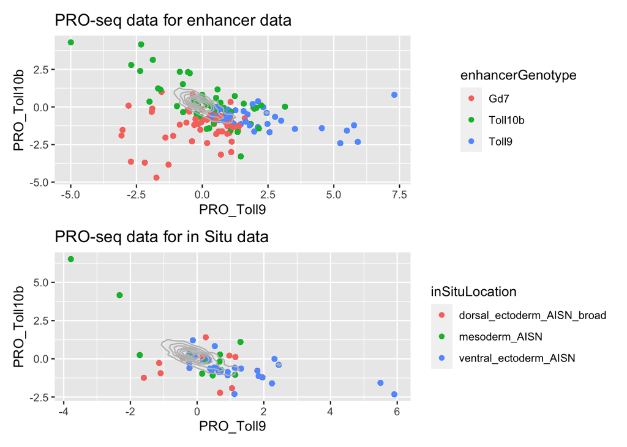

```r
# Here we plot the true positives dependent on which annotation and which data set it is.
PE =  EnhancerInfo %>% filter(enhancer == 1) %>% ggplot(aes(PRO_Toll9, PRO_Toll10b, color = enhancerGenotype)) +
  ggtitle("PRO-seq data for enhancer data") + geom_point() + geom_density_2d(EnhancerInfo,
                                                                             mapping = aes(PRO_Toll9, PRO_Toll10b),
                                                                             color = "grey")

PI =  EnhancerInfo %>% filter(inSitu == 1) %>% ggplot(aes(PRO_Toll9, PRO_Toll10b, color = inSituLocation)) +
  ggtitle("PRO-seq data for in Situ data") + geom_point() + geom_density_2d(EnhancerInfo,
                                                                            mapping = aes(PRO_Toll9, PRO_Toll10b),
                                                                            color = "grey")
AE =  EnhancerInfo %>% filter(enhancer == 1) %>% ggplot(aes(ATAC_Toll9, ATAC_Toll10b, color = enhancerGenotype)) + geom_point() + geom_density_2d(EnhancerInfo,
                                                                                                                                                  mapping = aes(ATAC_Toll9, ATAC_Toll10b),
                                                                                                                                                  color = "grey")
AI =  EnhancerInfo %>% filter(inSitu == 1) %>% ggplot(aes(ATAC_Toll9, ATAC_Toll10b, color = inSituLocation)) + geom_point() + geom_density_2d(EnhancerInfo,
                                                                                                                                              mapping = aes(ATAC_Toll9, ATAC_Toll10b),
                                                                                                                                              color = "grey")
CE =  EnhancerInfo %>% filter(enhancer == 1) %>% ggplot(aes(CBP_Toll9, CBP_Toll10b, color = enhancerGenotype)) + geom_point() + geom_density_2d(EnhancerInfo,
                                                                                                                                                mapping = aes(CBP_Toll9, CBP_Toll10b),
                                                                                                                                                color = "grey")
CI =  EnhancerInfo %>% filter(inSitu == 1) %>% ggplot(aes(CBP_Toll9, CBP_Toll10b, color = inSituLocation)) + geom_point() + geom_density_2d(EnhancerInfo,
                                                                                                                                            mapping = aes(CBP_Toll9, CBP_Toll10b),
                                                                                                                                            color = "grey")
KE =  EnhancerInfo %>% filter(enhancer == 1) %>% ggplot(aes(K27ac_Toll9, K27ac_Toll10b, color = enhancerGenotype)) + geom_point() + geom_density_2d(EnhancerInfo,
                                                                                                                                                    mapping = aes(K27ac_Toll9, K27ac_Toll10b),
                                                                                                                                                    color = "grey") + ggtitle("Enhancer data for H3K27ac")
KI =  EnhancerInfo %>% filter(inSitu == 1) %>% ggplot(aes(K27ac_Toll9, K27ac_Toll10b, color = inSituLocation)) + geom_point() + geom_density_2d(EnhancerInfo,
                                                                                                                                                mapping = aes(K27ac_Toll9, K27ac_Toll10b),
                                                                                                                                                color = "grey") + ggtitle("In Situ data for H3K27ac")
# Execute to output the plots
PE + PI + plot_layout(ncol = 1)
```

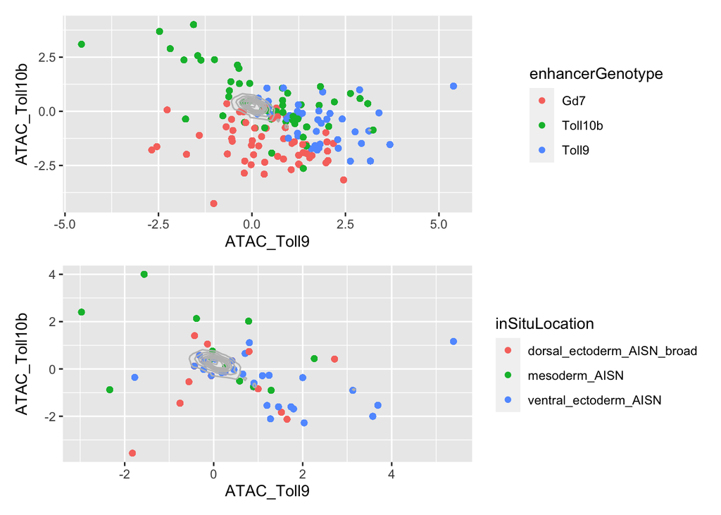

```r
AE + AI + plot_layout(ncol = 1)
```

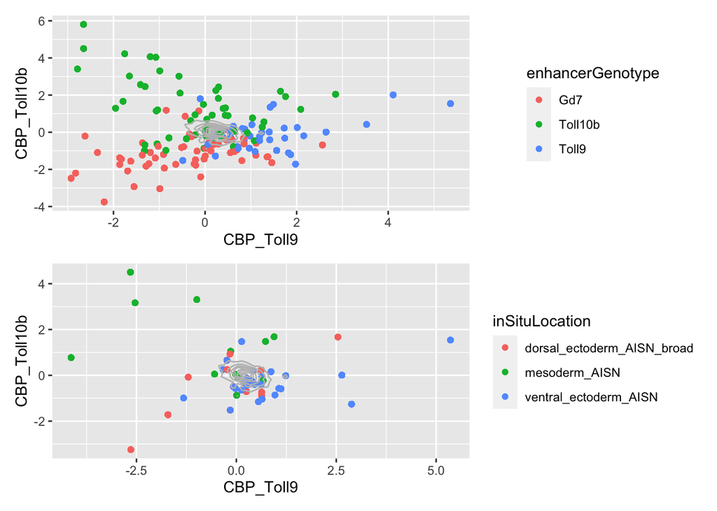

```r
CE + CI + plot_layout(ncol = 1)
```

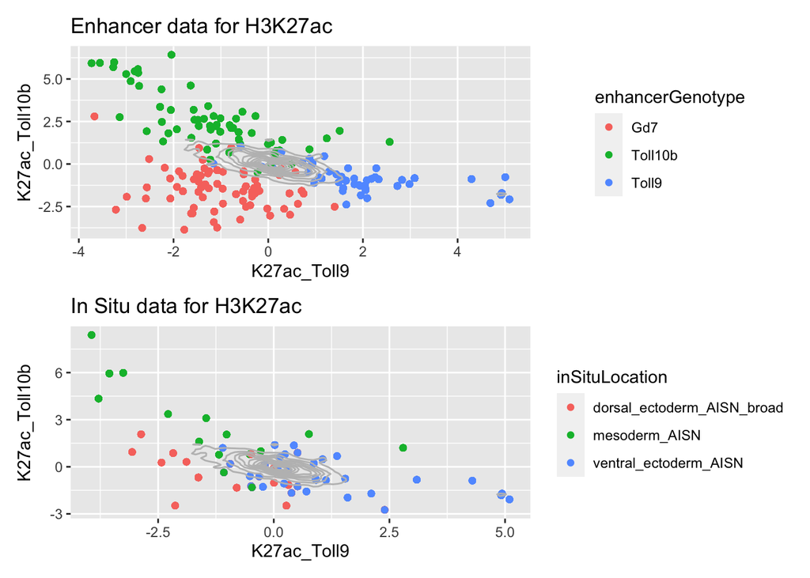

```r
KE + KI + plot_layout(ncol = 1)
```

## Principal component analysis We now combine the data to create a distance for all data. Principal component analysis once again reduces the dimensions and creates a loading score. These loading score are then used as a distance. The five first PCs are seen as the most important. Five distances are created. Distance one is just the absolute value of PC1. Distance 2 is the distance between PC1 and PC2 and so forth until distance five is the distance in the 5D space of PC1-5.

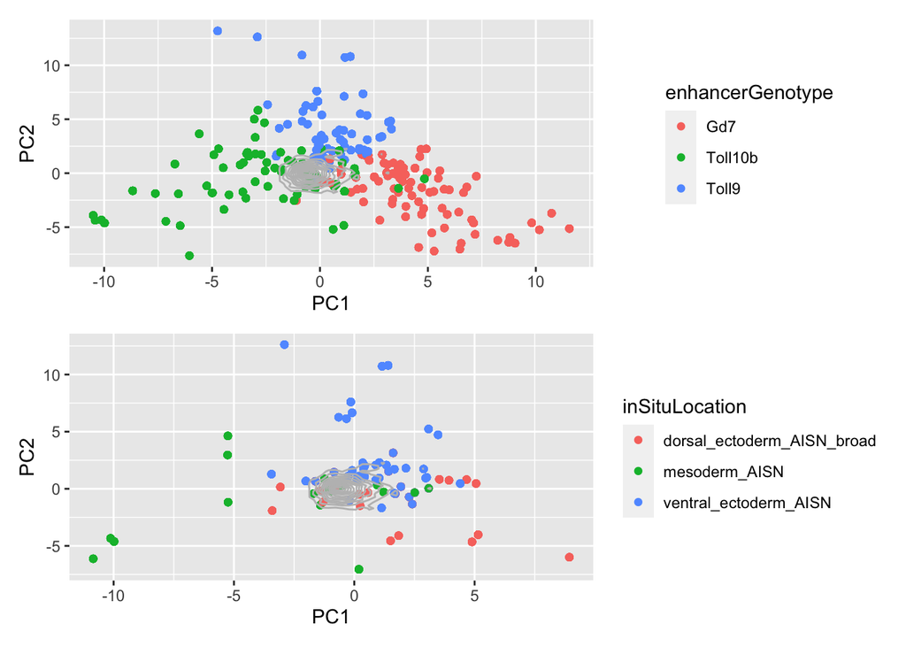

```r
# Plots to visualize the first two PCs which contain the most variance
FE =  AllData %>% filter(enhancer == 1) %>% ggplot(aes(PC1, PC2, color = enhancerGenotype )) + geom_point()+ geom_density_2d(AllData,mapping = aes(PC1, PC2), color= "grey")
FI =  AllData %>% filter(inSitu == 1) %>% ggplot(aes(PC1, PC2, color = inSituLocation )) + geom_point()+ geom_density_2d(AllData,mapping = aes(PC1, PC2), color= "grey")
# Need to execute to output the plots
FE + FI+ plot_layout(ncol = 1)
```

## Assesment with ROC curves

We now have identified true positives in our data, by in situ and enhancer data respectively.

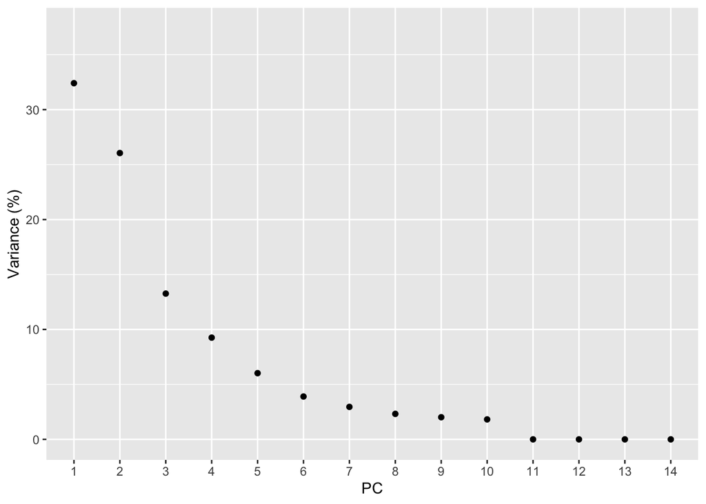

```r
qplot(
  PC,
  Variance,
  data = e.var,
  geom = c("point")
  ,
  ylim = c(0, max(e.var$Variance) + 5)
  ,
  ylab = "Variance (%)"
)
```

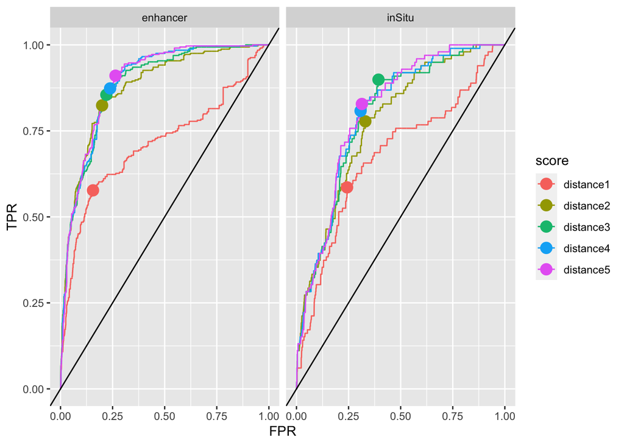

```r
ggplot(ROCplotInfo, mapping =  aes(x = FPR, y = TPR, color = score)) +
  geom_line() +
  geom_abline() +
  geom_point(
    data = ROCplotSummary,
    mapping = aes(y = TPR, x = FPR, color = score),
    size = 4
  ) +
  facet_grid(. ~ classifier)
```

## Enhancer selection Based on ROC statistics it is best if we include all five PC. Therefore the distance5 is the score that is selected. The data is selected based on a Youden score. The enhancers below the cutoff will be classified as background enhancers.

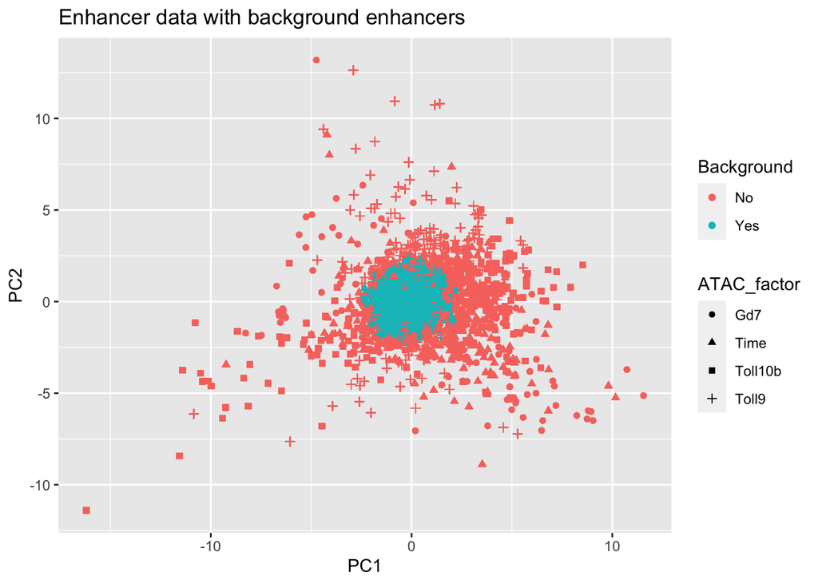

```r
scores = ROCplotSummary %>% dplyr::filter(classifier == "enhancer" &
                                            score == "distance5")
AllData.enhancers = AllData
AllData.enhancers$Background = "Yes"
AllData.enhancers$Background[AllData$distance5 > scores$YoudenCutoff] = "No"
AllData.enhancers = AllData.enhancers %>% replace_na(
  list(
    enhancerID = "None",
    enhancerGenotype = "None",
    insituID = "None",
    inSituLocation = "None",
    inSituScore = -1
  )
)
peakInfo = data.frame(ATAC_peakData)
peakInfo$geneID = names(ATAC_peakData)
AllData.enhancers = AllData.enhancers %>% dplyr::select(-geneID_unique)
AllData.enhancers = inner_join(peakInfo, AllData.enhancers, by = "geneID")

# Plot to find how many background enhancers and where in the 2D space of PC1 and PC2 they are
ggplot(AllData.enhancers, mapping =  aes(x = PC1, y = PC2, color = Background, shape=ATAC_factor)) + geom_point() + ggtitle("Enhancer data with background enhancers")
```

## Combine and polish the results

### Combine the scores to a single enhanecers core

Combine the score of the ATAC-seq, ChIP-seq and PRO-seq data to a single score for each mutant. The bigger the score, the more important it is for that mutant.

```r
AllData_test = AllData.enhancers %>% mutate(Enhancer_Gd7 =  ATAC_Gd7 + CBP_Gd7 + K27ac_Gd7 +
                                              PRO_Gd7)
AllData_test = AllData_test %>% mutate(Enhancer_Toll10b =  ATAC_Toll10b + CBP_Toll10b + K27ac_Toll10b +
                                         PRO_Toll10b)
AllData_test = AllData_test %>% mutate(Enhancer_Toll9 =  ATAC_Toll9 + CBP_Toll9 + K27ac_Toll9 +
                                         PRO_Toll9)
AllData_test = AllData_test %>% mutate(Enhancer_Time =  ATAC_Time + PRO_Time)
```

### Save the data

```r
enhancers.filtering = AllData_test %>% dplyr::select(
  geneID,
  Chr,
  ATAC_Start,
  ATAC_End,
  ATAC_factor,
  ATAC_direction,
  enhancerID,
  insituID,
  Enhancer_Gd7,
  Enhancer_Toll10b,
  Enhancer_Toll9,
  Enhancer_Time,
  Background
) %>% unique()

write.table(
  x = enhancers.filtering,
  file = paste(params$workingDir, params$results_file , sep = "/"),
  quote = F,
  sep = "\t",
  row.names = F,
  col.names = T
)
```